# R Notebook

```r
library(tidyverse)
library(lubridate)
library(tsibble)
library(here)
library(reshape2)
library(ggplot2)
library(infer)
library(scales)
```

```r
covid_age_sex_hb <- read_csv(here("raw_data/covid_data/hospital_admissions_hb_agesex_20220302.csv"))
covid_simd_hb <-read_csv(here("raw_data/covid_data/hospital_admissions_hb_simd_20220302.csv"))
covid_specialty_hb <- read_csv(here("raw_data/covid_data/hospital_admissions_hb_specialty_20220302.csv"))
hb <- read_csv(here("raw_data/general/hb14_hb19.csv")) %>% janitor::clean_names()
```

———— cleaning ——— I will clean 3 hb related data set and join them together at the end

2.3. Data transformations including data cleaning ### Create date from the week_ending columns and select ### the useful columns that we will be looking at.

```r
covid_age_sex_short <- covid_age_sex_hb %>% janitor::clean_names() %>%
  select(c(week_ending, hb, age_group, sex, admission_type, number_admissions, average20182019, percent_variation)) %>%
  mutate(week_ending = as.Date(ymd(week_ending)))
```

```r
covid_simd_short <- covid_simd_hb %>% janitor::clean_names() %>%
  select(c(week_ending, hb, simd_quintile, admission_type, number_admissions, average20182019, percent_variation)) %>%
  mutate(week_ending = as.Date(ymd(week_ending)))
```

```r
covid_specialty_short <- covid_specialty_hb %>% janitor::clean_names() %>%
  select(c(week_ending, hb, specialty, admission_type, number_admissions, average20182019, percent_variation)) %>%
  mutate(week_ending = as.Date(ymd(week_ending)))
```

```r
covid_hb <- covid_age_sex_short %>% full_join(covid_simd_short)%>% full_join(covid_specialty_short)
```

2.5. Exploratory data analysis emergency vs planned admission type overall count

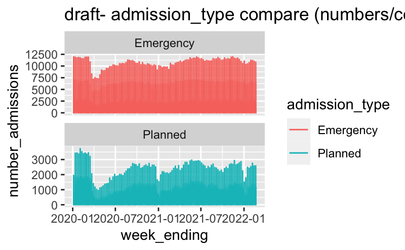

```r
covid_hb %>%
  filter(admission_type %in% c("Emergency","Planned")) %>%
  drop_na(number_admissions) %>%
  ggplot(aes(week_ending, number_admissions))+
  geom_line(aes(col = admission_type), group = 1)+
  facet_wrap( ~ admission_type, ncol = 1, scales = "free_y")+
  labs(title = "draft- admission_type compare (numbers/counts)")
```

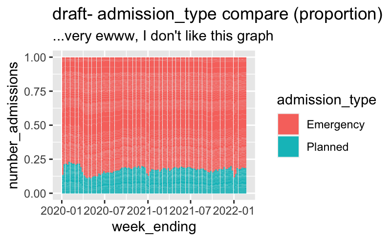

```r
covid_hb %>%
  filter(admission_type %in% c("Emergency","Planned")) %>%
  drop_na(number_admissions) %>%
  ggplot(aes(week_ending, number_admissions))+
  geom_col(aes(fill = admission_type), position = "fill")+
  labs(title = "draft- admission_type compare (proportion)",
       subtitle = "...very ewww, I don't like this graph")
```

—–emergency— tidyed a bit (all group by week, mean of all hb)

```r
covid_emergency <- covid_hb %>%
  group_by(week_ending) %>%
  filter(admission_type == "Emergency",
         age_group == "All ages",
         sex == "All",
         specialty == "All") %>%
  summarise(mean_this_week = mean(number_admissions),
            mean_1819 = mean(average20182019),
            var = mean(percent_variation))
```

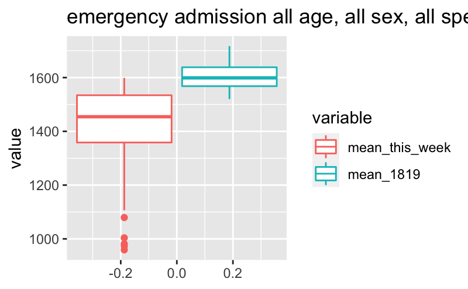

```r
data_mod_emergency <- melt(covid_emergency,
                  measure.vars=c('mean_this_week', 'mean_1819'))


ggplot(data_mod_emergency) +
geom_boxplot(aes(y=value, color=variable))+
  labs(title = "emergency admission all age, all sex, all specialty, mean of all hb")
```

2.6. Statistical analyses to identify patterns, trends and relationships in the dataset ### Over time trend of percent variation for emergency admissions

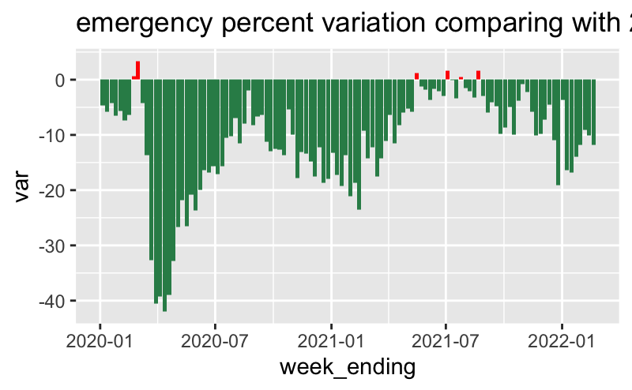

```r
covid_emergency %>%
  ggplot(aes(week_ending, var)) +
    geom_col(fill = case_when(covid_emergency$var >= 0 ~"red",
                              TRUE ~ "seagreen"))+
  labs(title = "emergency percent variation comparing with 2018/2019 ")
```

——-planned ——- repeated as emergency

```r
covid_planned <- covid_hb %>%
  group_by(week_ending) %>%
  filter(admission_type == "Planned",
         age_group == "All ages",
         sex == "All",
         specialty == "All") %>%
  summarise(mean_this_week = mean(number_admissions),
            mean_1819 = mean(average20182019),
            var = mean(percent_variation))
```

```r
data_mod_planned <- melt(covid_planned,
                  measure.vars=c('mean_this_week', 'mean_1819'))


ggplot(data_mod_planned) +
geom_boxplot(aes(y=value, color=variable))+
  labs(title = "plannedadmission all age, all sex, all specialty, mean of all hb",
       subtitle = "why why why ")
```

[output not shown]

```r
covid_planned %>%
  ggplot(aes(week_ending, var)) +
    geom_col(fill = case_when(covid_planned$var >= 0 ~"red",
                              TRUE ~ "seagreen"))+
  labs(title = "draft-planned percent variation comparing with 2018/2019 ",
       subtitle = "why! i don' understand, i must have done something wrong",
       fill = "fix it later")
```

[output not shown]

—-I will add few more cols for analysis later —–

```r
covid_full <- hb %>% janitor::clean_names() %>%
  select(1,2) %>%
right_join(covid_hb,by = "hb")

covid_full <- covid_full %>% mutate(
  year = year(week_ending),
  month = month(week_ending,label = TRUE),
  .after = week_ending
)


covid_full %>% head()
```

[output not shown]

—–gender——